# measure horseshoe bat call : Documentation

[figure not shown]

Automate measurements of horseshoe bat calls - (or any similar sound!).

## What is a horseshoe bat call - why have I never heard one before?

Don’t know - no worries! Haven’t heard one before? No surprise - they’re literally in the ultrasonic range(>=40kHz frequency).

However, if you really want to imagine what it’d be like if you could hear them, this is what a horseshoe bat call would sound like. You can do this by slowing down the horseshoe bat calls by a *lot* (10X)!

[interactive chart not shown]

As you may have heard in the playback - the horseshoe bat call sounds like a whistle with a ‘rising’ part, a constant part and a ‘descending’ part. These are technically known as the rising frequency modulation (FM), constant frequency (CF) and the descending FM parts of a horseshoe bat call. Not all calls have both rising and descending, and some calls may have only the rising FM or the descending FM. The relative durations of the Cf and FM are also known to change depending on the behavioural context at hand. When plotted on a spectrogram, people have described the call to resemble a table (side-profile) or a staple-pin - and this is where the logo of this package comes from!

## What *is* a horseshoe bat, and why is it calling?

Horseshoe bats are a type of nocturnal bat that have strange looking noses (and thus the name) and emit the characteristic ‘table-top’/‘staple-pin’ type echolocation calls. They emit these calls and listen for the returning echoes from these calls to detect obstacles and prey around them.

## What does this package do and does it only work with horseshoe (Rhinolophidae) bat calls?

It’s all in the name. It measures various properties of a horseshoe bat call. The package is *not* specific to only Rhinolophid bat calls! The packages is so named only because it was developed originally for two Rhinolophid species. If you have leaf-nosed(Hipposiderid) bat calls - this package should work too.

Essentially any sound with a constant frequency flanked on either side by frequency modulations will be handled correctly!

Given a call, the package segments out CF and FM components and calculates various measures. The FM and CF parts are separated in the waveform and various measurements are made on them including:

- CF peak frequency
- FM end frequency/ies
- CF and FM durations
- CF and FM rms and energy

## Who is this package useful for?

Mainly those studying bat calls, and in specific those analysing horseshoe/leaf-nosed bat calls. However, there may perhaps be a whole host of sounds which looks similar – and so it might also be useful for the analysis of any sound that looks like a bat CF call!

## Why did you develop this package?

Measuring the sub-structure of horseshoe bat calls can be tiresome and error-prone when done manually. While the human eye can recognise the CF and FM parts of the call very well, segmenting it consistently is hard to do. This is because we rely on a spectrographic representation - the settings of which again influences how a call is segmented into FM and CF. Even existing automated methods in the field rely on spectrographic representations. Moreover, to my knowledge, there aren’t any open-source tools developed specifically to measre call parameters for horseshoe bat calls.

## Acknowledgements

The example data is a subset of audio recorded of *Rhinolophus mehelyi* and *Rhinolophus euryale* bats as they flew in and out of an evening roosting spot. Data collection was done by Neetash MR and Thejasvi Beleyur. Audio data annotation and selection done by Aditya Krishna.

I thank Neetash MR, Diana Schoeppler & Holger R Goerlitz for their inputs in the development of this package.

## How do I use this package?

## Installation:

This package works with both Python 2 and 3. Download the package using pip with:

`pip install measure_horseshoebat_calls`

or

download this repo from Github,open up a terminal window, navigate to the folder, and type:

`python setup.py install`

## Usage:

The measure_horseshoe_bat_calls package takes in an audio file snippet with a *single* horseshoe bat call in it and outputs various measures of this call. Let us first load a manually selected part of a recording with a single horseshoe bat call in it.

```python
# import package and required modules
%matplotlib notebook
import measure_horseshoe_bat_calls
from measure_horseshoe_bat_calls import measure_a_horseshoe_bat_call as measure
from measure_horseshoe_bat_calls import segment_horseshoebat_call as segment
from measure_horseshoe_bat_calls.view_horseshoebat_call import *
from measure_horseshoe_bat_calls import data
```

```python
# load a short audio file with manually annotated data
chosen_audio = data.example_calls[25]
fs = data.fs

# view the waveform + spectrogram
visualise_call(chosen_audio, fs)
```

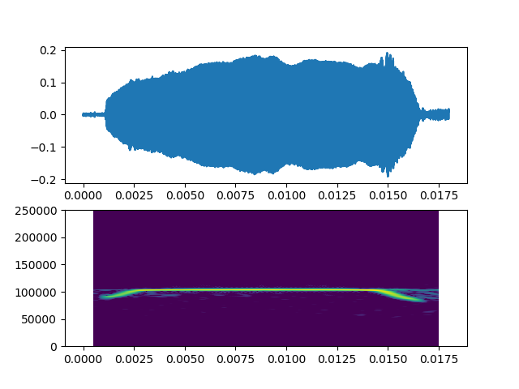

```
<IPython.core.display.Javascript object>
```

```
(<matplotlib.axes._subplots.AxesSubplot at 0x11e905c0>,
 <matplotlib.axes._subplots.AxesSubplot at 0x409b400>)
```

## Segmenting the call from the silent background.

Measuring temporal features such as call, CF and FM durations relies on an accurate and tight window selection that includes the call without too much of the background. Having more ‘background’ in the analyses will lead to inaccurate measurements of all parameters eg. duration and rms. Selecting a tight window can be simply done by hand, but also yields inconsistent results each time. Automating this process allows reproducibility across time.

```python
# get a tight window which only has the call.
main_call_window, call_profile = segment.segment_call_from_background(chosen_audio, fs,
                                                                          background_threshold=-20)
```

```python
waveform, specgram = check_call_background_segmentation(chosen_audio, fs, main_call_window)
# choose a tighter ylim to see the call better
specgram.set_ylim(50000, 125000)
```

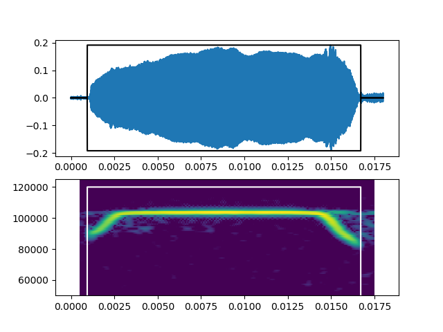

```
<IPython.core.display.Javascript object>
```

```
(50000, 125000)
```

## Segmenting a horseshoe bat call into the FM and CF components:

To actually quantitatively characterise a horseshoe bat call we first need to define the constant frequency (CF) and frequency modulated (FM) parts of it.

```python
# choose only the call without any background
only_call = chosen_audio[main_call_window]
```

```python
cf, fm, info = segment.segment_call_into_cf_fm(only_call, fs, percentage_peak=0.99)
```

```python
wave, spec = check_call_parts_segmentation(only_call, fs, cf, fm)
spec.set_ylim(50000, 120000)
```

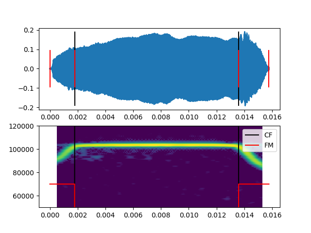

```
<IPython.core.display.Javascript object>
```

```
(50000, 120000)
```

```python
call_parts, measurements = measure.measure_hbc_call(only_call, fs, cf, fm)
```

```python
spec = make_overview_figure(only_call, fs, measurements)
spec.set_ylim(70000, 125000)
```

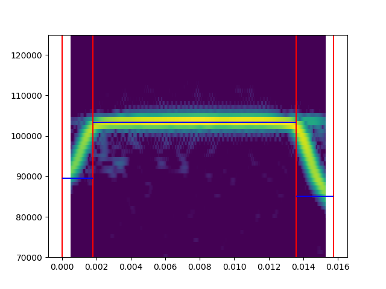

```
<IPython.core.display.Javascript object>
```

```
(70000, 125000)
```

## Understanding the measurements and overview figure:

The plot above shows start and stop times of the FMs in red. The blue lines along the FM indicate the lowest frequency (at -X dB threshold) and are drawn over the duration of the entire FM segment. The blue line in the CF is drawn at the call peak frequency and is drawn over the duration of the CF portion.

```python
measurements
```

```
{'call_duration': 0.015774,
 'call_energy': 82.03420564756195,
 'call_rms': 0.10198623706522475,
 'cf_duration': 0.011802,
 'cf_end': 0.013586,
 'cf_energy': 70.5245541075025,
 'cf_peak_frequency': 103372.30977800372,
 'cf_rms': 0.10932194936686337,
 'cf_start': 0.001786,
 'downfm_duration': 0.002186,
 'downfm_end': 0.015772,
 'downfm_energy': 8.692437077021435,
 'downfm_rms': 0.08917860958299323,
 'downfm_start': 0.013588,
 'downfm_terminal_frequency': 85086.91674290942,
 'peak_frequency': 103397.99670343605,
 'terminal_frequency_threshold': -10,
 'upfm_duration': 0.001786,
 'upfm_end': 0.001784,
 'upfm_energy': 2.8172144630380025,
 'upfm_rms': 0.05616738764205647,
 'upfm_start': 0.0,
 'upfm_terminal_frequency': 89585.66629339306}
```

## The call parts : CF and FM

```python
show_all_call_parts(only_call, call_parts, fs)
```

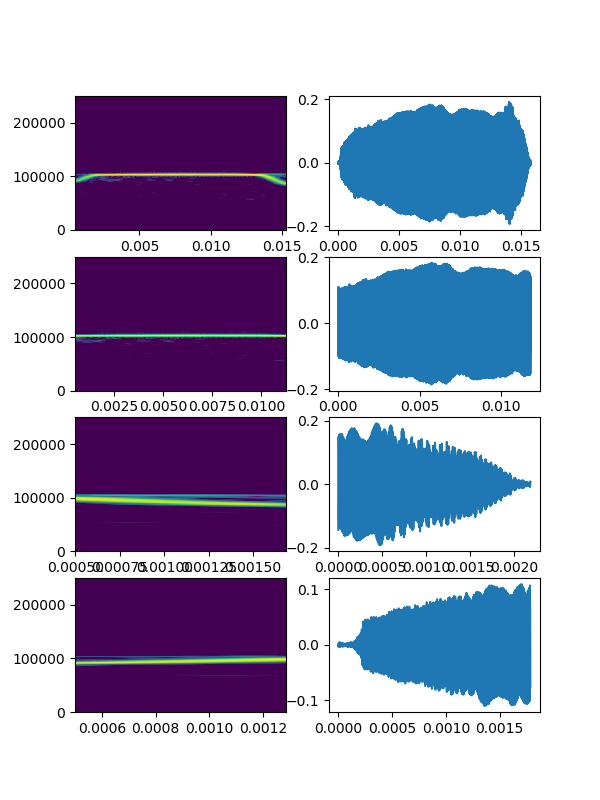

```
<IPython.core.display.Javascript object>
```

## Choosing the right parameter settings for *your* bat calls!

The segmentation is of course affected by the parameter settings given to `measure_hbc_call`. The current default set may be good for many situations - but you may want better!

## Under the hood : how does the horseshoe bat call segmentation actually work?

The call segmentation works on the fact that horseshoe bat calls have a relatively stereotyped structure. The CF part of a call is typically flanked by one or two FMs. `segment_call_into_cf_fm` goes through the following steps for every input audio.

### 1. Call-background segmentation:

Separate call from background by running a continuous wavelet transform on the audio. The coefficients of all scales with centre frequencies in the signal range are summed up. This forms a kind of the calls ‘energy profile’ - but only within the relevant frequencies. This approach tracks the onset and offset of the signal with high temporal resolution.

```python
main_call_window, call_profile = segment.segment_call_from_background(chosen_audio, fs,
                                                                          background_threshold=-20)
plt.figure()
a0 =plt.subplot(211)
make_waveform(call_profile, fs)
make_waveform(main_call_window*-20,fs) # show the region above the threshold
plt.ylabel('In band profile \n dBrms re max')
plt.subplot(212, sharex=a0)
plt.specgram(chosen_audio, Fs=fs);
```

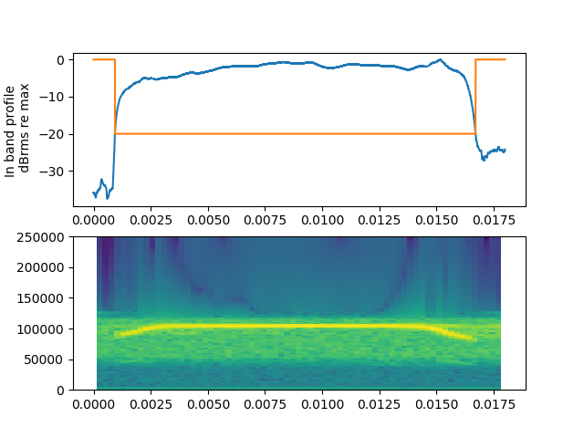

```
<IPython.core.display.Javascript object>
```

```python
# remove background
narrow_call_selection = chosen_audio[main_call_window]
```

### 2. Form FM dominant and CF dominant versions of the call:

```python
# calculate dB rms profile for low-passed and high-passed audio
cf_dbrms, fm_dbrms = segment.pre_process_for_segmentation(narrow_call_selection, fs)

plt.figure()
b0 = plt.subplot(211)
plt.plot(make_x_time(cf_dbrms, fs), cf_dbrms, label='CF dominant dBrms')
plt.plot(make_x_time(fm_dbrms, fs), fm_dbrms, label='FM dominant dBrms')
plt.ylabel('Filtered signal profile, dBrms')
plt.legend()
plt.subplot(212, sharex=b0)
plt.specgram(narrow_call_selection, Fs=fs);
```

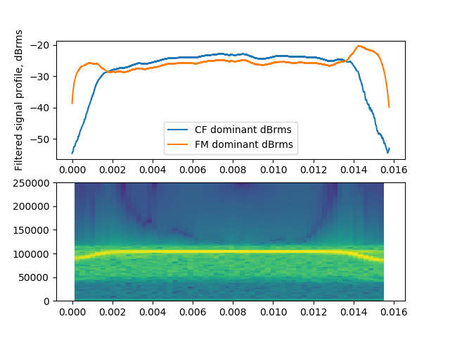

```
<IPython.core.display.Javascript object>
```

```python
# subtract the two from each other and see which regions they are relatively higher than the other.
main_cf, main_fm, [cf_re_fm, fm_re_cf] = segment.segment_cf_and_fm(cf_dbrms, fm_dbrms, fs)
```

```python
plt.figure()
c0 = plt.subplot(211)
plt.plot(make_x_time(cf_re_fm, fs), cf_re_fm, label='CF profile ref. FM profile')
plt.plot(make_x_time(fm_re_cf, fs), fm_re_cf, label='FM profile ref. CF profile')
plt.ylabel('Relative signal profile, dB')
plt.legend()
plt.subplot(212, sharex=c0)
plt.specgram(narrow_call_selection, Fs=fs);
```

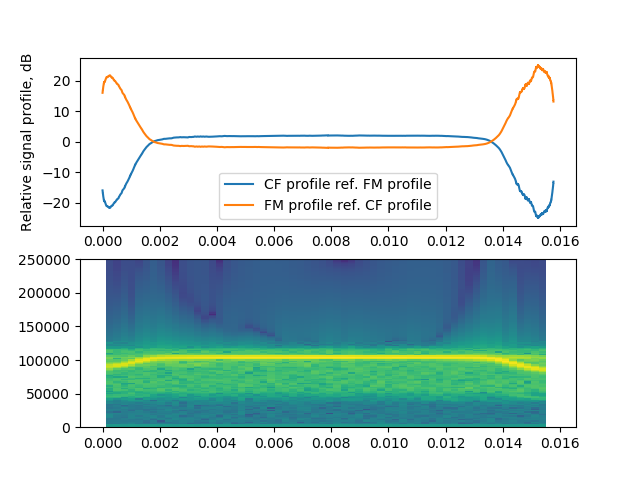

```
<IPython.core.display.Javascript object>
```

## Feedback and Contributions Welcome!!

If you think you have some vocalisations/sounds that look like a horseshoe bat call on a spectrogram, and you think it’s not being analysed quite right yet - do write to me with example data, I’d be happy to look into it.

## Author: Thejasvi Beleyur, Acoustic and Functional Ecology Group, Max Planck Institute for Ornithology, Seewiesen

– Last updated 2020-03-13

## How the package works

The package assumes that any given sound could have a set of three elements

- Constant Frequency (CF) : a pure tone like element
- Frequency Modulated (FM) : an element with a varying frequency
- Gap : a silence between two elements that is neither a CF nor an FM.

Any input audio goes through the following steps:

1. Time frequency localisation within audio: either one of STFT, WignerVille, instantaneous frequency
2. FM rate calculation : regions with modulation below the set limit are considered CF, and those above the FM rate are considered FM.
3. Rough candidate region assignment into CF and FM regions
4. Refined sample-level assignment into CF,FM and Gap regions based on user-input constraints (max number of elements, presence/absence of gaps, etc)
5. Segmentation of assigned elements and measurements of various parameters (peak frequency, energy, duration,…)

## High-level API

User-friendly top-level functions which allow the user to handle

1. Call-background segmentation
2. CF-FM call part segmentation
3. Measurement of CF-FM audio parts

```python
import scipy.signal as signal
from measure_horseshoe_bat_calls.user_interface import segment_and_measure_call
from measure_horseshoe_bat_calls.view_horseshoebat_call import *
from measure_horseshoe_bat_calls.simulate_calls import make_cffm_call

# create synthetic call
call_parameters = {'cf':(100000, 0.01),
                    'upfm':(80000, 0.002),
                    'downfm':(60000, 0.003),
                    }

fs = 500*10**3 # 500kHz sampling rate
synthetic_call, freq_profile = make_cffm_call(call_parameters, fs)

# window and reduce overall signal level
synthetic_call *= signal.tukey(synthetic_call.size, 0.1)
synthetic_call *= 0.75

# measuring a well-selected call (without silent background)



# measuing a call with a silent background

# and add 2ms of additional background_noise of ~ -60dBrms
samples_1ms = int(fs*0.001)
final_size = synthetic_call.size + samples_1ms*2
call_with_noise = np.random.normal(0,10**(-60/20.0),final_size)
call_with_noise[samples_1ms:-samples_1ms] += synthetic_call

#

seg_and_msmts = segment_and_measure_call(call_with_noise, fs,
                                         segment_from_background=True)
call_segmentation, call_parts, measurements, backg_segment = seg_and_msmts
```

**`measure_horseshoe_bat_calls.user_interface.``segment_and_measure_call`(*main_call*, *fs*, *segment_from_background=False*, **kwargs)[source]**

Segments the CF and FM parts of a call and then proceeds to measure their characteristics. If required, also segments call from background.

**Parameters**

- **main_call** (*np.array*) –
- **fs** (*float>0*) – sampling rate in Hz
- **segment_from_background** (*boolean*) – Whether to segment the call in the main_call audio. Defaults to False.

**Keyword Arguments**

**Returns**

- **segmentation_outputs** (*tuple*) – The outputs of segment_call_into_cf_fm in a tuple
- **call_parts** (*dictionary*) – Dictionary with ‘cf’ and ‘fm’ entries and corresponding audio.
- **measurements** (*dictionary*) – All the measurements from the FM and CF parts. For details see measure_a_horseshoe_bat_call
- **backg_segmentation_info** (*dictionary*) – Contains the output from segment_call_from_background + a copy of main_call, the raw un-segmented audio with background. The objects are accessed with the following keys: ‘raw_audio’, ‘call_mask’, ‘call_backg_info’.

**`measure_horseshoe_bat_calls.user_interface.``save_overview_graphs`(*all_subplots*, *analysis_name*, *file_name*, *index*, **kwargs)[source]**

Saves overview graphs.

**Parameters**

- **all_subplots** (*list*) – List with plt.subplot objects in them. For each figure to be saved, one subplot object is enough.
- **analysis_name** (*str*) – The name of the analysis. If this funciton is called through a batchfile, then it becomes the name of the batchfile
- **file_name** (*str*) –
- **index** (*int**,* *optional*) – A numeric identifier for each graph. This is especially relevant for analyses driven by batch files as there may be cases where the calls are selected from the same audio file but in different parts.

**Returns**

**Return type**

None

Notes

This function has the main side effect of saving all the input figures into a pdf file with >1 pages (one page per plot) for the user to inspect the results.

Example

import numpy as np

# 1st plot plt.figure() a = plt.subplot(211) plt.plot([1,2,3]) b = plt.subplot(212) plt.plot([5,4,3])

#2nd plot plt.figure() c = plt.subplot(121) plt.plot(np.random.normal(0,1,100)) d = plt.subplot(122) plt.plot(np.random.normal(0,1,10))

save_overview_graphs([a,c], ‘example_plots’, ‘example_file’,0)

## Batch processing from batchfiles

Runs the batch processing option. The main outputs are the call measurements and the visualisations.

```bash
$ python -m measure-horseshoe-bat-calls -batchfile template_batchfile.csv
```

**`measure_horseshoe_bat_calls.batch_processing.``run_from_batchfile`(*batchfile_path*)[source]**

**Parameters**

**batchfile_path** (*str/path*) – Path to a batchfile

**`measure_horseshoe_bat_calls.batch_processing.``save_measurements_to_file`(*output_filepath*, *audio_file_name*, *previous_rows*, *measurements*, *row_number*)[source]**

Thanks to tmss @ https://stackoverflow.com/a/46775108

**Parameters**

- **output_filepath** (*str/path*) –
- **previous_rows** (*pd.DataFrame*) – All the previous measurements. Can also just have a single row.
- **row_data** (*dictionary*) –
- **row_number** (*int*) –

**Returns**

**Return type**

None

Notes

Main side effect is to write an updated version of the output file.

**`measure_horseshoe_bat_calls.batch_processing.``load_raw_audio`(*kwargs*)[source]**

Takes a dictioanry input. All the parameter names need to be keys in the input dictionary.

**Parameters**

- **audio_path** (*str/path*) – Path to audio file
- **channel** (*int**,* *optional*) – Channel number to be loaded - starting from 1! Defaults to 1.
- **start****,****stop** (*float**,* *optional*) –

**Returns**

**raw_audio** – The audio corresponding to the start and stop times and the required channel.

**Return type**

np.array

**`measure_horseshoe_bat_calls.batch_processing.``to_separate_from_background`(*arguments*)[source]**

**`measure_horseshoe_bat_calls.batch_processing.``parse_batchfile_row`(*one_row*)[source]**

checks for all user-given arguments and removes any columns with DEFAULT in them.

**Parameters**

**one_row** (*pd.DataFrame*) – A single row with multiple column names, corresponding to compulsory required arguments and the optional ones

**Returns**

**arguments** – Simple dictioanry with one entry for each key.

**Return type**

dictionary

## Call -background and call-part segmentation

**`measure_horseshoe_bat_calls.segment_horseshoebat_call.``segment_call_into_cf_fm`(*call*, *fs*, **kwargs)[source]**

Function which identifies regions into CF and FM based on the following process.

1. Candidate regions of CF and FM are first produced based on the segmentation method chosen’.

2. These candidate regions are then refined based on the user’s requirements (minimum length of region, maximum number of CF/FM regions in the sound)

3. The finalised CF and FM regions are output as Boolean arrays.

**Parameters**

- **call** (*np.array*) – Audio with horseshoe bat call
- **fs** (*float>0*) – Frequency of sampling in Hz.
- **method** (*str**,* *optional*) – One of [‘peak_percentage’, ‘pwvd’, ‘inst_freq’]. Checkout ‘See Also’ for more information. Defaults to ‘peak_percentage’

**Returns**

- **cf_samples, fm_samples** (*np.array*) – Boolean numpy array showing which of the samples belong to the cf and the fm respectively.
- **info** (*dictionary*) – Post-processing information depending on the methods used.

See also

`segment_by_peak_percentage()`, `segment_by_pwvd()`, `segment_by_inst_frequency()`

Notes

The post-processing information in the object info depends on the method used.

**`measure_horseshoe_bat_calls.segment_horseshoebat_call.``segment_by_peak_percentage`(*call*, *fs*, **kwargs)[source]**

This is ideal for calls with one clear CF section with the CF portion being the highest frequency in the call: bat/bird CF-FM calls which have on CF and one/two sweep section.

Calculates the peak frequency of the whole call and performs low+high pass filtering at a frequency slightly lower than the peak frequency.

**Parameters**

- **call** (*np.array*) –
- **fs** (*float>0*) –

**Returns**

- **cf_samples, fm_samples** (*np.array*) – Boolean array with True indicating that sample has been categorised as being CF and/or FM.
- **info** (*dictionary*) – With keys ‘fm_re_cf’ and ‘cf_re_fm’ indicating the relative dBrms profiles of the candidate FM regions relative to Cf and vice versa.

Notes

This method unsuited for audio with non-uniform call envelopes. When there is high variation over the call envelope, the peak frequency is likely to be miscalculated, and thus lead to wrong segmentation.

This method is somewhat inspired by the protocol in Schoeppler et al. 2018. However, it differs in the important aspect of being done entirely in the time domain. Schoeppler et al. 2018 use a spectrogram based method to segment the CF and FM segments of H. armiger calls.

References

[1] Schoeppler, D., Schnitzler, H. U., & Denzinger, A. (2018). Precise Doppler shift compensation in the hipposiderid bat, Hipposideros armiger. Scientific Reports, 8(1), 1-11.

See also

`pre_process_for_segmentation()`

**`measure_horseshoe_bat_calls.segment_horseshoebat_call.``segment_by_pwvd`(*call*, *fs*, **kwargs)[source]**

This method is technically more accurate in segmenting CF and FM portions of a sound. The Pseudo-Wigner-Ville Distribution of the input signal is generated.

**Parameters**

- **call** (*np.array*) –
- **fs** (*float>0*) –
- **fmrate_threshold** (*float >=0*) – The threshold rate of frequency modulation in kHz/ms. Beyond this value a segment of audio is considered a frequency modulated region. Defaults to 0.5 kHz/ms

**Returns**

- **cf_samples, fm_samples** (*np.array*) – Boolean array of same size as call indicating candidate CF and FM regions.
- **info** (*dictionary*) – See get_pwvd_frequency_profile for the keys it outputs in the info dictioanry. In addition, another key ‘fmrate’ is also calculated which has an np. array with the rate of frequency modulation across the signal in kHz/ms.

Notes

This method may takes some time to run. It is computationally intensive. This method may not work very well in the presence of multiple harmonics or noise. Some basic tweaking of the optional parameters may be required.

See also

`get_pwvd_frequency_profile()`

**`measure_horseshoe_bat_calls.segment_horseshoebat_call.``calculate_fm_rate`(*frequency_profile*, *fs*, **kwargs)[source]**

A frequency profile is generally oversampled. This means that there will be many repeated values and sometimes minor drops in frequency over time. This leads to more apparent FM than is actually there when a sample-wise diff is performed.

This method downsamples the frequency profile, fits a quadratic polynomial to it and then gets the smoothened frequency profile with unique values.

The sample-level FM rate can now be calculated reliably.

**Parameters**

- **frequency_profile** (*np.array*) – Array of same size as the original audio. Each sample has the estimated instantaneous frequency in Hz.
- **fs** (*sampling rate*) –

**`measure_horseshoe_bat_calls.segment_horseshoebat_call.``refine_candidate_regions`()[source]**

Takes in candidate CF and FM regions and tries to satisfy the constraints set by the user.

**`measure_horseshoe_bat_calls.segment_horseshoebat_call.``check_segment_cf_and_fm`(*cf_samples*, *fm_samples*, *fs*, **kwargs)[source]**

**`measure_horseshoe_bat_calls.segment_horseshoebat_call.``get_cf_region`(*cf_samples*, *fs*, **kwargs)[source]**

TODO : generalise to multiple CF regions

**Parameters**

- **cf_samples** (*np.array*) – Boolean with True indicating a Cf region.
- **fs** (*float*) –

**Returns**

**cf_region** – The longest continuous stretch

**Return type**

np.array

**`measure_horseshoe_bat_calls.segment_horseshoebat_call.``get_fm_regions`(*fm_samples*, *fs*, **kwargs)[source]**

**Returns**

**valid_fm** – Boolean numpy array with the corrected fm samples.

**Return type**

np.array

**`measure_horseshoe_bat_calls.segment_horseshoebat_call.``segment_call_from_background`(*audio*, *fs*, **kwargs)[source]**

Performs a wavelet transform to track the signal within the relevant portion of the bandwidth.

This methods broadly works by summing up all the signal content above the `` `lowest_relevant_frequency` `` using a continuous wavelet transform.

If the call-background segmentation doesn’t work well it’s probably due to one of these things:

1. Incorrect `background_threshold` : Play around with different `background_threshold values`.
2. Incorrect `lowest_relevant_frequency` : If the lowest relevant frequency is set outside of the signal’s actual frequency range, then the segmentation will fail. Try lower this parameter till you’re sure all of the signal’s spectral range is above it.
3. Low signal spectral range : This method uses a continuous wavelet transform to localise the relevant signal. Wavelet transforms have high temporal resolution in for high frequencies, but lower temporal resolutions for lower frequencies. If your signal is dominantly low-frequency, try resampling it to a lower sampling rate and see if this works?

If the above tricks don’t work, then try bandpassing your signal - may be it’s an issue with the in-band signal to noise ratio.

**Parameters**

- **audio** (*np.array*) –
- **fs** (*float>0*) – Frequency of sampling in Hertz.
- **lowest_relevant_freq** (*float>0**,* *optional*) – The lowest frequency band in Hz whose coefficients will be tracked. The coefficients of all frequencies in the signal >= the lowest relevant frequency are tracked. This is the lowest possible frequency the signal can take. It is best to give a few kHz of berth. Defaults to 35kHz.
- **background_threshold** (*float<0**,* *optional*) – The relative threshold which is used to define the background. The segmentation is performed by selecting the region that is above background_threshold dB relative to the max dB rms value in the audio. Defaults to -20 dB
- **wavelet_type** (*str**,* *optional*) – The type of wavelet which will be used for the continuous wavelet transform. Run pywt.wavelist(kind=’continuous’) for all possible types in case the default doesn’t seem to work. Defaults to mexican hat, ‘mexh’
- **scales** (*array-like**,* *optional*) – The scales to be used for the continuous wavelet transform. Defaults to np.arange(1,10).

**Returns**

- **potential_region** (*np.array*) – A boolean numpy array where True corresponds to the regions which are call samples, and False are the background samples. The single longest continuous region is output.
- **dbrms_profile** (*np.array*) – The dB rms profile of the summed up wavelet transform for all centre frequencies >= lowest_relevant_frequency.s

**Raises**

- **ValueError** – When lowest_relevant_frequency is too high or not included in the centre frequencies of the default/input scales for wavelet transforms.
- **IncorrectThreshold** – When the dynamic range of the relevant part of the signal is smaller or equal to the background_threshold.

**`measure_horseshoe_bat_calls.segment_horseshoebat_call.``identify_valid_regions`(*condition_satisfied*, *num_expected_regions=1*)[source]**

**Parameters**

- **condition_satisfied** (*np.array*) – Boolean numpy array with samples either being True or False. The array may have multiple regions which satisfy a conditions (True) separated by smaller regions which don’t (False).
- **num_expected_regions** (*int > 0*) – The number of expected regions which satisfy a condition. If >2, then the first two longest continuous regions will be returned, and the smaller regions will be suppressed/eliminated. Defaults to 1.

**Returns**

**valid_regions** – Boolean array which identifies the regions with the longest contiguous lengths.

**Return type**

np.array

**`measure_horseshoe_bat_calls.segment_horseshoebat_call.``identify_maximum_contiguous_regions`(*condition_satisfied*, *number_regions_of_interest=1*)[source]**

Given a Boolean array - this function identifies regions of contiguous samples that are true and labels each with its own region_number.

**Parameters**

- **condition_satisfied** (*np.array*) – Numpy array with Boolean (True/False) entries for each sample.
- **number_regions_of_interest** (*integer > 1*) – Number of contiguous regions which are to be detected. The region ids are output in descending order (longest–>shortest). Defaults to 1.

**Returns**

- **region_numbers** (*list*) – List with numeric IDs given to each contiguous region which is True.
- **region_id_and_samples** (*np.array*) – Two columns numpy array. Column 0 has the region_number, and Column 1 has the individual samples that belong to each region_number.

**`measure_horseshoe_bat_calls.segment_horseshoebat_call.``pre_process_for_segmentation`(*call*, *fs*, **kwargs)[source]**

Performs a series of steps on a raw cf call before passing it for temporal segmentation into cf and fm. Step 1: find peak frequency Step 2: lowpass (fm_audio) and highpass (cf_audio) below

> a fixed percentage of the peak frequency

Step 3: calculate the moving dB of the fm and cf audio

**Parameters**

- **call** (*np.array*) –
- **fs** (*int.*) – Frequency of sampling in Hertz
- **peak_percentage** (*0<float<1**,* *optional*) – This is the fraction of the peak at which low and high-pass filtering happens. Defaults to 0.98.
- **lowpass** (*optional*) – Custom lowpass filtering coefficients. See low_and_highpass_around_threshold
- **highpass** – Custom highpass filtering coefficients. See low_and_highpass_around_threshold
- **window_size** (*integer**,* *optional*) – The window size in samples over which the moving rms of the low+high passed signals will be calculated. For default value see documentation of moving_rms

**Returns**

**cf_dbrms, fm_dbrms** – The dB rms profile of the high + low passed versions of the input audio.

**Return type**

np.arrays

**`measure_horseshoe_bat_calls.segment_horseshoebat_call.``low_and_highpass_around_threshold`(*audio*, *fs*, *threshold_frequency*, **kwargs)[source]**

Make two version of an audio clip: the low pass and high pass versions.

**Parameters**

- **audio** (*np.array*) –
- **fs** (*float>0*) – Frequency of sampling in Hz
- **threshold_frequency** (*float>0*) – The frequency at which the lowpass and highpass operations are be done.
- **lowpass****,****highpass** (*ndarrays**,* *optional*) – The b & a polynomials of an IIR filter which define the lowpass and highpass filters. Defaults to a second order elliptical filter with rp of 3dB and rs of 10 dB. See signal.ellip for more details of rp and rs.
- **pad_duration** (*float>0**,* *optional*) – Zero-padding duration in seconds before low+high pass filtering. Defaults to 0.1 seconds.

**Returns**

**lp_audio, hp_audio** – The low and high pass filtered versions of the input audio.

**Return type**

np.arrays

**`measure_horseshoe_bat_calls.segment_horseshoebat_call.``get_thresholds_re_max`(*cf_dbrms*, *fm_dbrms*)[source]**

**`measure_horseshoe_bat_calls.segment_horseshoebat_call.``calc_proper_kernel_size`(*durn*, *fs*)[source]**

scipy.signal.medfilt requires an odd number of samples as kernel_size. This function calculates the number of samples for a given duration which is odd and is close to the required duration.

**Parameters**

- **durn** (*float*) – Duration in seconds.
- **fs** (*float*) – Sampling rate in Hz

**Returns**

**samples** – Number of odd samples that is equal to or little less (by one sample) than the input duration.

**Return type**

int

**`measure_horseshoe_bat_calls.segment_horseshoebat_call.``resize_by_adding_one_sample`(*input_signal*, *original_signal*, **kwargs)[source]**

Resizes the input_signal to the same size as the original signal by repeating one sample value. The sample value can either the last or the first sample of the input_signal.

**`measure_horseshoe_bat_calls.segment_horseshoebat_call.``median_filter`(*input_signal*, *fs*, **kwargs)[source]**

Median filters a signal according to a user-settable window size.

**Parameters**

- **input_signal** (*np.array*) –
- **fs** (*float*) – Sampling rate in Hz.
- **medianfilter_size** (*float**,* *optional*) – The window size in seconds. Defaults to 0.001 seconds.

**Returns**

**med_filtered** – Median filtered version of the input_signal.

**Return type**

np.array

**`measure_horseshoe_bat_calls.segment_horseshoebat_call.``identify_cf_ish_regions`(*frequency_profile*, *fs*, **kwargs)[source]**

Identifies CF regions by comparing the rate of frequency modulation across the signal. If the frequency modulation within a region of the signal is less than the limit then it is considered a CF region.

**Parameters**

- **frequency_profile** (*np.array*) – The instantaneous frequency of the signal over time in Hz.
- **fm_limit** (*float**,* *optional*) – The maximum rate of frequency modulation in Hz/s. Defaults to 1000 Hz/s
- **medianfilter_size** (*float**,* *optional*) –

**Returns**

- **cfish_regions** (*np.array*) – Boolean array where True indicates a low FM rate region. The output may still need to be cleaned before final use.
- *clean_fmrate_resized*

Notes

If you’re used to reading FM modulation rates in kHz/ms then just follow this relation to get the required modulation rate in Hz/s:

X kHz/ms = (X Hz/s)* 10^-6

OR

X Hz/s = (X kHz/ms) * 10^6

See also

`median_filter()`

**`measure_horseshoe_bat_calls.segment_horseshoebat_call.``segment_cf_regions`(*audio*, *fs*, **kwargs)[source]**

**exception* `measure_horseshoe_bat_calls.segment_horseshoebat_call.``CFIdentificationError`[source]**

**exception* `measure_horseshoe_bat_calls.segment_horseshoebat_call.``IncorrectThreshold`[source]**

## Call background and call-part segmentation: part 2

Once the frequency profile have been calculated, its ‘velocity’ must be measured to get the rate of frequency modulation. Once the FM rate can be calculated, the CF and FM parts of the sound can be segmented accurately.

The primary problems with estimated frequency profiles are :

1. Spikiness due to edge effects : when the background wasn’t succesfully isolated from the signal. This appears especially at the edges of the sound segments.
2. Repeated back-and-forth between somewhat disparate frequencies. Over the course of one samples, the instantaneous frequency can switch upto a few kHz. This is typically caused by harmonics or noise causing the well-known interference terms in the PWVD. This typically occurs in the middle of the signal itself.

## Call-parts measurements

Module that segments and measures parts of a CF-FM call.

**`measure_horseshoe_bat_calls.measure_a_horseshoe_bat_call.``measure_hbc_call`(*call*, *fs*, *cf_segment*, *fm_segment*, **kwargs)[source]**

Segments and measures a horseshoe bat call

**Parameters**

- **audio** (*np.array*) –
- **fs** (*float>0.*) – Frequency of sampling in Hz.
- **cf_segment** (*np.array*) – Boolean array with True indicating samples that define the CF
- **fm_segment** (*np.array*) – Boolean array with True indicating samples that define the FM

**Returns**

- **sound_segments** (*dictionary*) – Dictionary with keys ‘cf’ and ‘fm’. There is only one entry for ‘cf’ and upto two entries for ‘fm’.
- **measurements** (*pd.DataFrame*) – A single row of all the measurements.

**`measure_horseshoe_bat_calls.measure_a_horseshoe_bat_call.``get_fm_snippets`(*whole_call*, *fm_segments*, *fs*, *cf_startstop*)[source]**

Creates separate audio clips for each FM sweep and labels them as either ‘upfm’ or ‘downfm’

**Parameters**

- **whole_call** (*np.array*) – Whole call audio
- **fm_segments** (*np.array*) – Boolean numpy array with True indicating samples in the whole_call that are FM sweeps.
- **fs** (*float>0*) – Sampling rate in Hz
- **cf_startstop** (*tuple*) – The start and stop times of the CF segment in seconds.

**Returns**

- **fm_types** (*list*) – List with strings labelling the type of FM sweep. All sweeps ending in the first half of the call are labelled ‘upfm’ and those ending in the second half are labelled ‘downfm’. There can be 1 OR 2 entries in fm_types depending on the call segmentation results.
- **fm_audio** (*list*) – List with audio snippets
- **fm_boundaries** (*list*) – list with start and stop time of fm sweep in seconds.

**`measure_horseshoe_bat_calls.measure_a_horseshoe_bat_call.``make_one_CFcall`(*call_durn*, *fm_durn*, *cf_freq*, *fs*, *call_shape*, **kwargs)[source]**

A test function used to check how well the segmenting+measurement functions in the module work.

**Parameters**

- **call_durn** (*float*) –
- **fm_durn** (*float*) –
- **cf_freq** (*float*) –
- **fs** (*float*) –
- **call_shape** (*str*) – One of either ‘staplepin’ OR ‘rightangle’
- **fm_bandwidth** (*float**,* *optional*) – FM bandwidth in Hz.

**Returns**

**cfcall** – The synthesised call.

**Return type**

np.array

**Raises**

**ValueError** – If a call_shape that is not ‘staplepin’ OR ‘rightangle’ is given

Notes

This is not really the besssst kind of CF call to test the functions on, but it works okay. The CF call is made by using the poly spline function and this leads to weird jumps in frequency especially around the CF-FM junctions. Longish calls with decently long FM parts look fine, but calls with very short FM parts lead to rippling of the frequency.

**`measure_horseshoe_bat_calls.measure_a_horseshoe_bat_call.``which_fm_type`(*fm_startand_stop*, *cf_startstop*)[source]**

figures out whether its an up or down fm using the start and stop times. The distance between the midpoint of the fm segment and the cf start and stop points are calculated. If the cf start is closer to the fm midpoint the fm is considered a ‘upfm_’ and a ‘downfm_’ otherwise.

**Parameters**

**cf_startstop** (*fm_startand_stop**,*) – The start and stop time of the FM and CF segments in seconds.

**Returns**

**fm_type** – Either ‘upfm_’ or ‘downfm_’

**Return type**

str.

**`measure_horseshoe_bat_calls.measure_a_horseshoe_bat_call.``get_terminal_frequency`(*audio*, **kwargs)[source]**

Gives the -XdB frequency from the peak.

The power spectrum is calculated and smoothened over 3 frequency bands to remove complex comb-like structures.

Then the lowest frequency below XdB from the peak is returned.

**Parameters**

- **audio** (*np.array*) –
- **fs** (*float>0*) – Sampling rate in Hz
- **terminal_frequency_threshold** (*float**,* *optional*) – The terminal frequency is calculated based on finding the level of the peak frequency and choosing the lowest frequency which is -10 dB (20log10) below the peak level. Defaults to -10 dB

**Returns**

- *terminal_frequency*
- *threshold*

Notes

Careful about setting threshold too low - it might lead to output of terminal frequencies that are actually in the noise, and not part of the signal itself.

**exception* `measure_horseshoe_bat_calls.measure_a_horseshoe_bat_call.``FMIdentificationError`[source]**

**exception* `measure_horseshoe_bat_calls.measure_a_horseshoe_bat_call.``BackgroundSegmentationError`[source]**

## Call segmentation and measurements visualisation

Bunch of functions which help in visualising data and results

**`measure_horseshoe_bat_calls.view_horseshoebat_call.``check_call_background_segmentation`(*whole_call*, *fs*, *main_call_mask*, **kwargs)[source]**

Visualises the main call selection

**Parameters**

- **whole_call** (*np.array*) – Call audio
- **fs** (*float>0*) – Sampling rate in Hz
- **main_call_mask** (*np.array*) – Boolean array where True indicates the sample is part of the main call, and False that it is not.

**Returns**

**waveform, spec**

**Return type**

pyplot.subplots

Notes

The appearance of the two subplots can be further changes by varying the keyword arguments. For available keyword arguments see the visualise_call function.

**`measure_horseshoe_bat_calls.view_horseshoebat_call.``check_call_parts_segmentation`(*only_call*, *fs*, *cf*, *fm*, **kwargs)[source]**

**`measure_horseshoe_bat_calls.view_horseshoebat_call.``show_all_call_parts`(*only_call*, *call_parts*, *fs*, **kwargs)[source]**

**Parameters**

- **only_call** (*np.array*) –
- **call_parts** (*dictionary*) – Dictionary with keys ‘cf’ and ‘fm’ The entry for ‘cf’ should only have one audio segment. The entry for ‘fm’ can have multiple audio segments.
- **fs** (*float>0*) – Sampling rate in Hz.

**Returns**

**Return type**

None

Notes

For further keyword arguments to customise the spectrograms see documentation for make_specgram This function does not return any output, it only produces a figure with subplots.

**`measure_horseshoe_bat_calls.view_horseshoebat_call.``visualise_call`(*audio*, *fs*, **kwargs)[source]**

**Parameters**

- **audio** –
- **fs** –
- **fft_size** (*integer>0**,* *optional*) –

**Returns**

**a0, a1**

**Return type**

subplots

**`measure_horseshoe_bat_calls.view_horseshoebat_call.``make_specgram`(*audio*, *fs*, **kwargs)[source]**

**`measure_horseshoe_bat_calls.view_horseshoebat_call.``get_fftsize`(*fs*, **kwargs)[source]**

**`measure_horseshoe_bat_calls.view_horseshoebat_call.``make_overview_figure`(*call*, *fs*, *measurements*, **kwargs)[source]**

## Checking accuracy

The ‘simulate_calls’ module has functions which simulate CF-FM calls with parameters of choice. Let’s say we want to make a CF-FM call with the following parameters.

- CF portion at 100kHz and of 10ms length.
- up FM starting at 80kHz of 2ms
- down FM end at 60kHz of 3ms

The code snippet below recreates the call with the above parameters

```python
from measure_horseshoe_bat_calls.view_horseshoebat_call import visualise_call
from measure_horseshoe_bat_calls.simulate_calls import make_cffm_call

call_parameters = {'cf':(100000, 0.01),
                    'upfm':(80000, 0.002),
                    'downfm':(60000, 0.003),
                    }

fs = 500*10**3 # 500kHz sampling rate
synthetic_call, freq_profile = make_cffm_call(call_parameters, fs)

# plot
wavef, spec = visualise_call(synthetic_call, fs, fft_size=512)
spec.set_ylim(0,125000)
```

[output not shown]

Note

The ‘make_cffm_call’ makes simulated calls which match actual bat calls in all relevant aspects pretty well (temporal+spectral). However, there are still some issues to be sorted - for example, the level of the CF portion of the signal is always a little bit lower. If you have any suggestions for that it’d be great to hear. See `make_cffm_call()`, and `make_call_frequency_profile()` and `make_FM_with_joint()` for more details.

**`measure_horseshoe_bat_calls.simulate_calls.``make_cffm_call`(*call_properties*, *fs*, **kwargs)[source]**

**Parameters**

- **call_properties** (*dictionary*) – With keys corresponding to the upto 3 components cf, upfm, downfm See make_call_frequency_profile for further info.
- **fs** (*float>0*) – sampling rate in Hz
- **poly_order** (*int**,* *optional*) – see make_cffm_joint_profile
- **joint_duration** (*float**,* *optional*) – see make_cffm_joint_profile

**Returns**

**call, frequency_profile** – The audio and the final frequency profile.

**Return type**

np.array

See also

`make_call_frequency_profile()`

References

**..1 Thanks to Paul Panzer’s SO example code for forming the main basis for this function.**

https://stackoverflow.com/questions/47664360/list-of-frequencies-in-time-to-signal-in-python

**`measure_horseshoe_bat_calls.simulate_calls.``make_call_frequency_profile`(*call_properties*, *fs*, **kwargs)[source]**

**Parameters**

- **call_properties** (*dictionary*) – With keys : ‘cf’, ‘upfm’, ‘downfm’ Each key has a tuple entry with a frequency and a duration value
- **fs** (*float*) – Sampling rate in Hz

**Returns**

**final_frequency_profile** – The call frequency profile.

**Return type**

np.array

See also

`make_FM_with_joint()`

Example

This corresponds to a call with an upfm starting at 50kHz of 5ms and a CF at 100kHz of 10ms, followed by a downfm ending at 20kHz of 3ms.

```
>>> cp = {'cf':(100000, 0.01),
          'upfm':{50000, 0.005},
          'downfm':{20000, 0.003}}
>>> fs = 500000
>>> call_freq_profile = make_call_frequency_profile(cp, fs)
```

**`measure_horseshoe_bat_calls.simulate_calls.``make_FM_with_joint`(*fm_properties*, *cf_start*, *fs*, **kwargs)[source]**

Outputs an FM segment with the CF part of the joint attached. Think of it like a bent gamma ( $\Gamma$) with the part coming down at an angle instead.

**Parameters**

- **fm_properties** (*tuple*) – Tuple with format (end_frequency_Hz, fm_duration_seconds)
- **cf_start** (*float*) – CF frequency

See also

`make_cffm_joint_profile()`

**Returns**

**fm_with_joint** – Frequency profile of the FM segment with a bit of the CF part of the joint sticking out.

**Return type**

np.array

**`measure_horseshoe_bat_calls.simulate_calls.``make_cffm_joint_profile`(*cf*, *fm_slope*, *fs*, *joint_type='down'*, **kwargs)[source]**

Makes a ‘joint’ in the frequency profile at transition betweent eh CF and FM parts

**Parameters**

- **cf** (*float>0*) –
- **fm_slope** (*float>0*) –
- **fs** (*float>0*) –
- **poly_order** (*int**,* *optional*) – Polynomial order to be used by np.polyfit Defaults to 10
- **joint_duration** (*float**,* *optional*) – The length of the CF and FM joints. Default to 0.5 ms

**Returns**

**freq_profile** – Frequency at each sample point over the 2*joint_duration length array.

**Return type**

np.array

# Indices and tables

- Index
- Module Index
- Search Page